# Teenage Pregnancies in Greater Manchester (2017)

Rhian Davies

## Introduction

We have perfomed an analysis of the ONS conceptions data, available online on the [ONS website.](https://www.ons.gov.uk/peoplepopulationandcommunity/birthsdeathsandmarriages/conceptionandfertilityrates/datasets/conceptionstatisticsenglandandwalesreferencetables).

First we read in the processed data set.

```r
library("tidyverse")
df = read_csv(file = "../data/processed/conception_table_6.csv")
```

Here is a table summarising the data.

|  | la_code | la_name | stat | year | value |
| --- | --- | --- | --- | --- | --- |
| 1 | E92000001 | ENGLAND | conceptions_per_1000 | 2017 | 17.8 |
| 2 | E92000001 | ENGLAND | conceptions_per_1000 | 2016 | 18.8 |
| 3 | E92000001 | ENGLAND | conceptions_per_1000 | 2015 | 20.8 |
| 4 | E92000001 | ENGLAND | conceptions_per_1000 | 2014 | 22.8 |
| 5 | E92000001 | ENGLAND | conceptions_per_1000 | 2013 | 24.3 |
| 6 | E92000001 | ENGLAND | conceptions_per_1000 | 2012 | 27.7 |
| 7 | E92000001 | ENGLAND | conceptions_per_1000 | 2011 | 30.7 |
| 8 | E92000001 | ENGLAND | conceptions_per_1000 | 2010 | 34.2 |
| 9 | E92000001 | ENGLAND | conceptions_per_1000 | 2009 | 37.1 |
| 10 | E92000001 | ENGLAND | conceptions_per_1000 | 2008 | 39.7 |

[output cut: 250 more lines]

## Plotting

We decided to investigate how this statistic changes across the different local authorities of Greater Manchester.

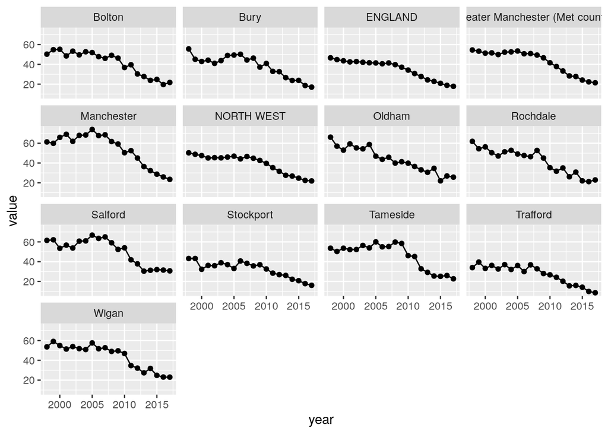

# Creating maps

It makes sense to represent some of this data on a map. In order to do this, we need a shapefile of Greater Manchester. We’ve downloaded the Local Authority Districts shape file from the [Open Geography Portal](http://geoportal.statistics.gov.uk/).

[figure not shown]

# Leaflet map

We then dediced to create a interactive map, using the same dataset above, but instead using the **leaflet** package.

In order to colour the polygons by the values, we had to first create our own palette function. We then used that palette function in the fillColor argument.

[interactive chart not shown]